# Hierarchical Models, Random Samples, Statistics, Sampling Distributions, and the Central Limit Theorem

Ashish Dasu

The Central Limit Theorem and the properties of estimators are some of the most powerful statistical concepts/tools. Let us use our simulation tools to visualize the theory behind them.

# 1 Heirarchichal Models

$$T \sim \text{Gamma}(\alpha = 10, \beta
= 4), \quad Y|T \sim \text{Pois}(T)$$
Function Y models the random variable $Y$ and takes input values $\alpha$ and $\beta$.

```r
Y <- function(alpha, beta) {
  T <- rgamma(1, shape = alpha, rate = beta)
  Y <- rpois(1, lambda = T)
  return(Y)
}
```

Using the replicate function to get 10000 values of the random variable $Y$ and storing these values in ‘y_empirical’

```r
alpha <- 10
beta <- 4
y_empirical <- replicate(10000, Y(alpha, beta))
```

Using the ‘hist’ function to calculate the empirical distribution of $Y$.

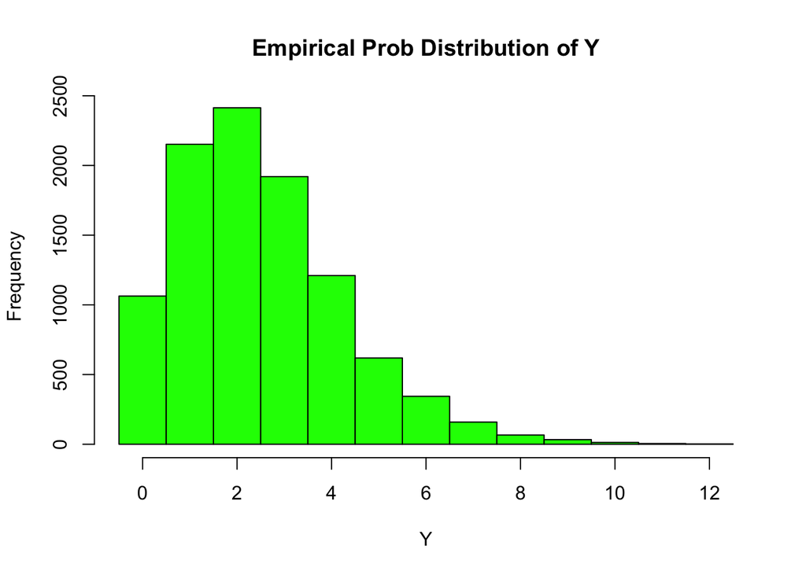

```r
hist(breaks=(min(y_empirical-.5):max(y_empirical+.5)), y_empirical,col = "green", xlab = "Y", ylab = "Frequency", main = "Empirical Prob Distribution of Y")
```

Now getting 10000 random values from the appropriate negative binomial distribution, and storing these in the variable ‘y_theoretical’. Using the ‘qqplot’ function to compare the quantiles of ‘y_empirical’ to those of ‘y_theoretical’.

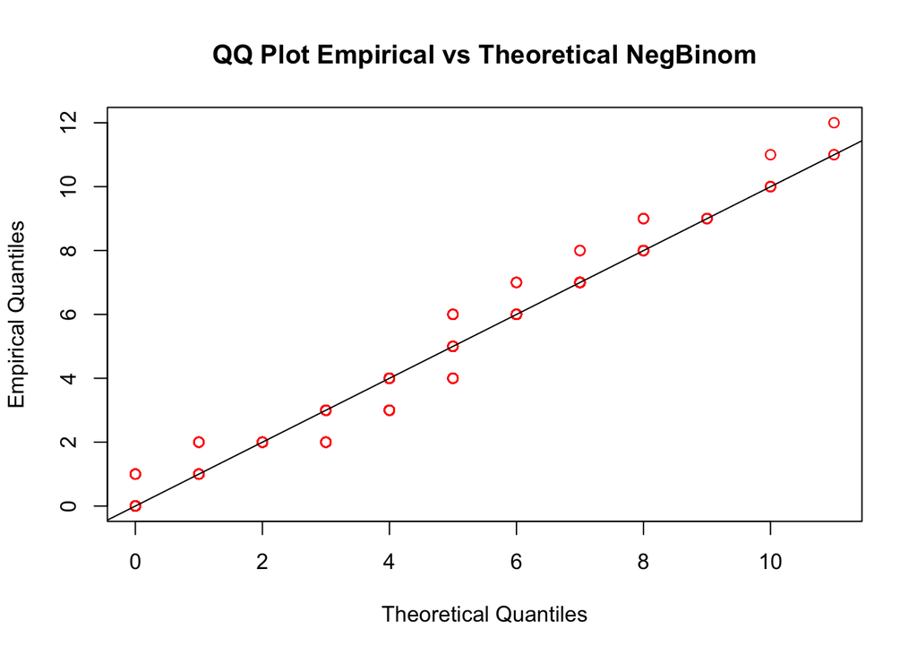

```r
y_theoretical <- rnbinom(10000, size=10, prob=4/5)

qqplot(y_theoretical, y_empirical,ylab = "Empirical Quantiles", xlab = "Theoretical Quantiles", main = "QQ Plot Empirical vs Theoretical NegBinom", col='red')
abline(0,1)
```

```r
# We see that the quantiles are quite similar, thus both distributions are approximately the same.
```

# 2 Markov’s and Chebychev’s Bounds.

Given a random variable $X$ with mean $\mu$ and variance $\sigma^2$, we have Markov’s bound given as (for $a >0$)
$$P(X\ge a) \le \frac{\mu}{a},$$
and Chebychev’s bound given by (for $k>0$):
$$P(|X-\mu|\ge k ) \le \frac{\sigma^2}{k^2}.$$
Functions “markov” and “chebychev” take relevant inputs ($a, \mu$ for Markov and $k, \sigma^2$ for Chebychev) and output the relevant value of their bounds.

```r
markov <- function(alpha, mu) {
    return(mu/alpha)
}

chebychev <- function(k, var) {
    return(var/k^2)
}

colors <- c('blue', 'green', 'red', 'purple', 'steelblue', 'maroon', 'turquoise', 'magenta', 'orange', 'navy', 'darkgreen')
```

## 2.1 Normal distribution

For values of $a\in (14, 22)$ plotting the true value of $P(X\ge a)$ and the Markovs bound on the same plot ($x$-axis will be $(14, 22)$) when $X\sim N(\mu = 18, \sigma = 1.5)$.

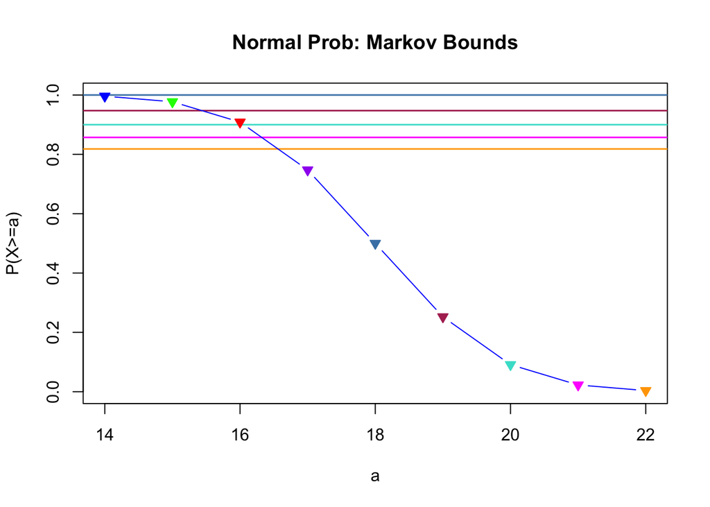

```r
X <- c()
plot(x=NULL, xlim = c(14,22), y=NULL, ylim = c(0,1), main='Normal Prob: Markov Bounds', xlab='a', ylab='P(X>=a)', col='black')

for (i in 14:22) {
    abline(lwd=1.5, h=markov(i, 18), col=colors[i-13])
    X <- c(X, (1 - pnorm(i, mean=18, sd=1.5)))
}
points(type='b', x=14:22, y=X, bg=colors, col=colors, pch=25)
```

For values of $k\in (0,5)$ plotting the true value of $P(|X-\mu_X|\ge k)$ and the Chebychev’s bound, on the same plot ($x$-axis will be $(0,5)$) when $X\sim N(\mu = 18, \sigma = 1.5)$.

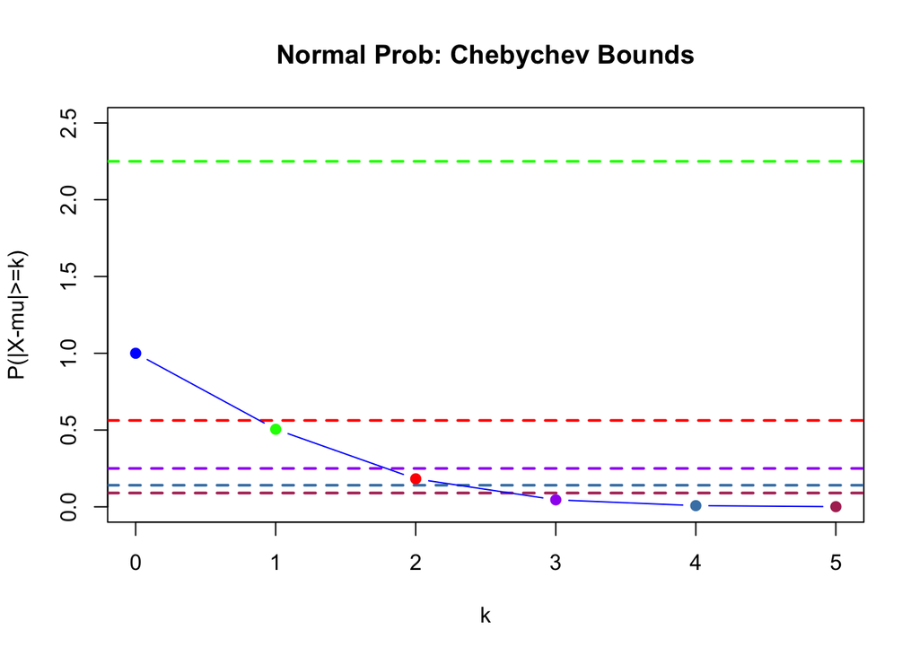

```r
plot(x=NULL, xlim = c(0,5), y=NULL, ylim = c(0,2.5), main='Normal Prob: Chebychev Bounds', xlab='k', ylab='P(|X-mu|>=k)', col='black')

Z <- c()
for (k in 0:5) {
    abline(lwd=2, lty='dashed', h=chebychev(k, 1.5^2), col=colors[k+1])
    Z <- c(Z, (1 - pnorm(k, mean=0, sd=1.5) + pnorm(-k, mean=0, sd=1.5)))
}

points(type='b', x=0:5, y=Z, bg=colors, col=colors, pch=21)
```

## 2.2 Exponential Distribution

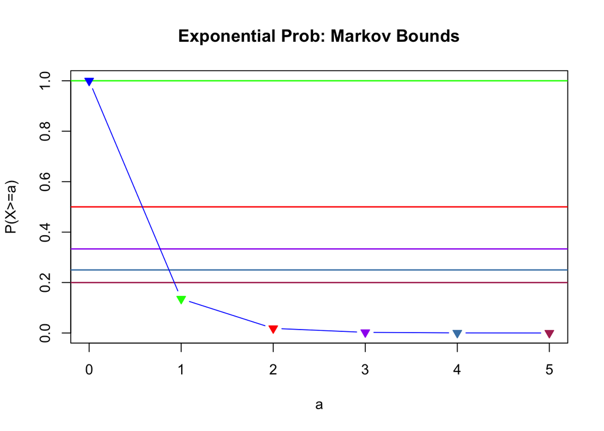

```r
plot(x=NULL, xlim = c(0,5), y=NULL, ylim = c(0,1), main='Exponential Prob: Markov Bounds', xlab='a', ylab='P(X>=a)', col='black')

X <- c()
for (i in 0:5) {
    abline(lwd=1.5, h=markov(i, 1), col=colors[i+1])
    X <- c(X, 1 - pexp(i, rate=2))
}
points(type='b', x=0:5, y=X, bg=colors, col=colors, pch=25)
```

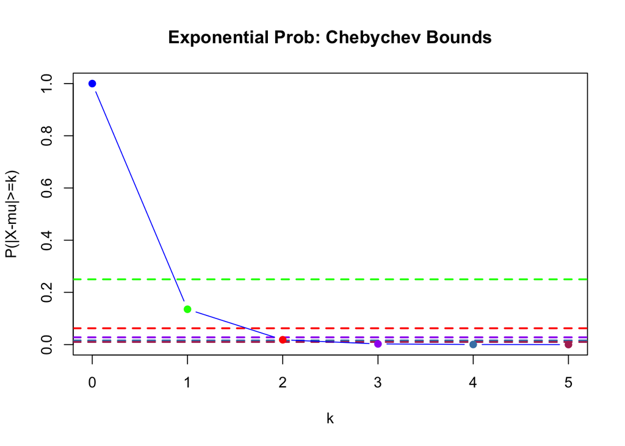

```r
plot(x=NULL, xlim = c(0,5), y=NULL, ylim = c(0,1), main='Exponential Prob: Chebychev Bounds', xlab='k', ylab='P(|X-mu|>=k)', col='black')

Z <- c()
for (k in 0:5) {
    abline(lwd=2, lty='dashed', h=chebychev(k, .5^2), col=colors[k+1])
    Z <- c(Z, (1 - pexp(k, rate=2) + pexp(-k, rate=2)))
}

points(type='b', x=0:5, y=Z, bg=colors, col=colors, pch=21)
```